# COMPSCIX 415.2 Homework 2

Inessa Wu

February 6, 2018

```r
library(tidyverse)
```

#### Exercises 3.2.4

```r
ggplot2::mpg
```

| manufacturer | model | displ | year | cyl | trans | drv | cty | hwy | fl | class |
| --- | --- | --- | --- | --- | --- | --- | --- | --- | --- | --- |
| audi | a4 | 1.8 | 1999 | 4 | auto(l5) | f | 18 | 29 | p | compact |
| audi | a4 | 1.8 | 1999 | 4 | manual(m5) | f | 21 | 29 | p | compact |
| audi | a4 | 2.0 | 2008 | 4 | manual(m6) | f | 20 | 31 | p | compact |
| audi | a4 | 2.0 | 2008 | 4 | auto(av) | f | 21 | 30 | p | compact |
| audi | a4 | 2.8 | 1999 | 6 | auto(l5) | f | 16 | 26 | p | compact |
| audi | a4 | 2.8 | 1999 | 6 | manual(m5) | f | 18 | 26 | p | compact |
| audi | a4 | 3.1 | 2008 | 6 | auto(av) | f | 18 | 27 | p | compact |
| audi | a4 quattro | 1.8 | 1999 | 4 | manual(m5) | 4 | 18 | 26 | p | compact |
| audi | a4 quattro | 1.8 | 1999 | 4 | auto(l5) | 4 | 16 | 25 | p | compact |
| audi | a4 quattro | 2.0 | 2008 | 4 | manual(m6) | 4 | 20 | 28 | p | compact |

[output cut: 224 more lines]

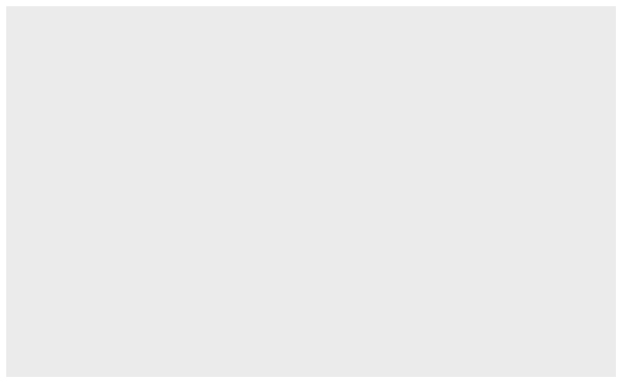

```r
ggplot(data=mpg)
```

##### 1. I see just the graphing template, nothing plotted

```r
glimpse(mpg)
```

```
Observations: 234
Variables: 11
$ manufacturer <chr> "audi", "audi", "audi", "audi", "audi", "audi", "audi", "audi", "audi"...
$ model        <chr> "a4", "a4", "a4", "a4", "a4", "a4", "a4", "a4 quattro", "a4 quattro", ...
$ displ        <dbl> 1.8, 1.8, 2.0, 2.0, 2.8, 2.8, 3.1, 1.8, 1.8, 2.0, 2.0, 2.8, 2.8, 3.1, ...
$ year         <int> 1999, 1999, 2008, 2008, 1999, 1999, 2008, 1999, 1999, 2008, 2008, 1999...
$ cyl          <int> 4, 4, 4, 4, 6, 6, 6, 4, 4, 4, 4, 6, 6, 6, 6, 6, 6, 8, 8, 8, 8, 8, 8, 8...
$ trans        <chr> "auto(l5)", "manual(m5)", "manual(m6)", "auto(av)", "auto(l5)", "manua...
$ drv          <chr> "f", "f", "f", "f", "f", "f", "f", "4", "4", "4", "4", "4", "4", "4", ...
$ cty          <int> 18, 21, 20, 21, 16, 18, 18, 18, 16, 20, 19, 15, 17, 17, 15, 15, 17, 16...
$ hwy          <int> 29, 29, 31, 30, 26, 26, 27, 26, 25, 28, 27, 25, 25, 25, 25, 24, 25, 23...
$ fl           <chr> "p", "p", "p", "p", "p", "p", "p", "p", "p", "p", "p", "p", "p", "p", ...
$ class        <chr> "compact", "compact", "compact", "compact", "compact", "compact", "com...
```

##### 2. 234 rows (observations); 11 columns (variables); drv is f = front-wheel drive, r = rear wheel drive, 4 = 4wd

```r
?mpg
```

##### 3. drv describes how torque is provided to the wheels

##### 4.

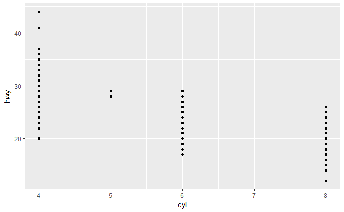

```r
ggplot(data = mpg) +
  geom_point(mapping = aes(x = cyl, y = hwy))
```

##### 5.

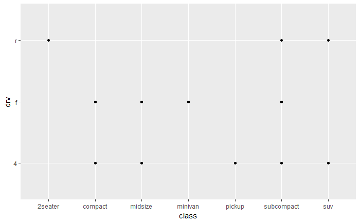

```r
ggplot(data = mpg) +
  geom_point(mapping = aes(x = class, y = drv))
```

##### graph does not make sense because it does not communicate any insights

### Exercises 3.3.1

##### 1. Data points are not blue because the manually set aethetic - color - needs to be set outside of aes()

##### 2. Categorical variables: model, year, trans, drv, fl, class; Continuous variables: despl, cyl, cty, hwy. Can look at the portion of the dataset by typing glipse(mpg)

##### 3.

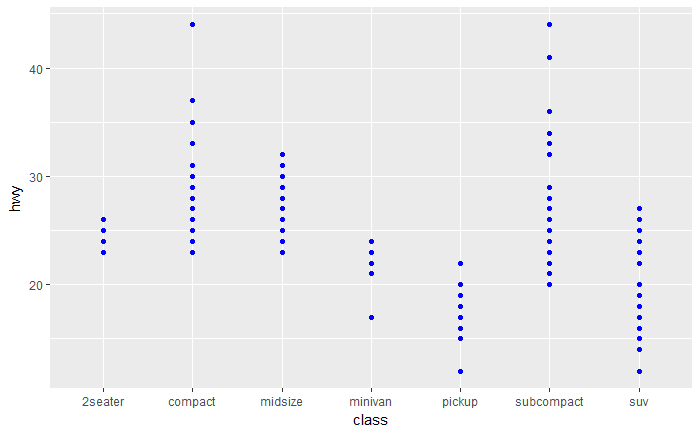

```r
ggplot(data = mpg) +
  geom_point(mapping = aes(x = class, y = hwy), color="blue")
```

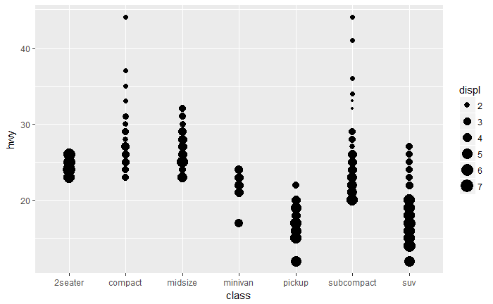

```r
ggplot(data = mpg) +
  geom_point(mapping = aes(x = class, y = hwy, size=displ))
```

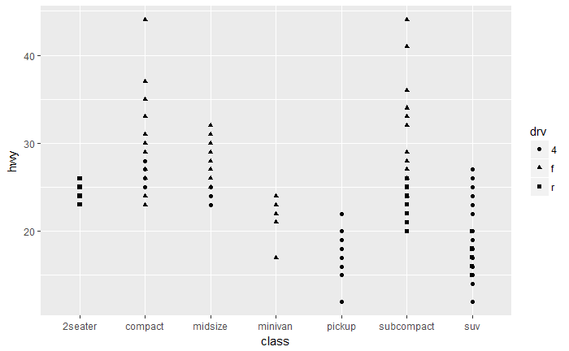

```r
ggplot(data = mpg) +
  geom_point(mapping = aes(x = class, y = hwy, shape=drv))
```

##### 4.

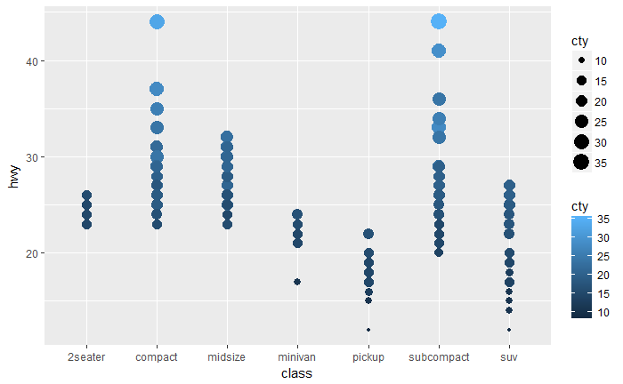

```r
ggplot(data = mpg) +
  geom_point(mapping = aes(x = class, y = hwy, color=cty, size=cty))
```

##### mapping the same variable to multiple aesthetics combines and defines the output according t o both aesthetics, in this case color and size

##### 5. Stroke aesthetic to modify the width of the border. works with shapes 21-24 - must have fill color and border

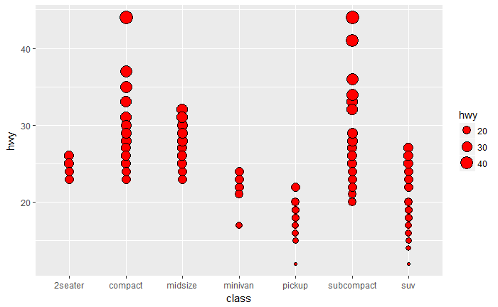

```r
ggplot(data=mpg)+
  geom_point(mapping=aes(x = class, y = hwy, size=hwy), shape=21, fill="red", stroke=1)
```

##### 6.

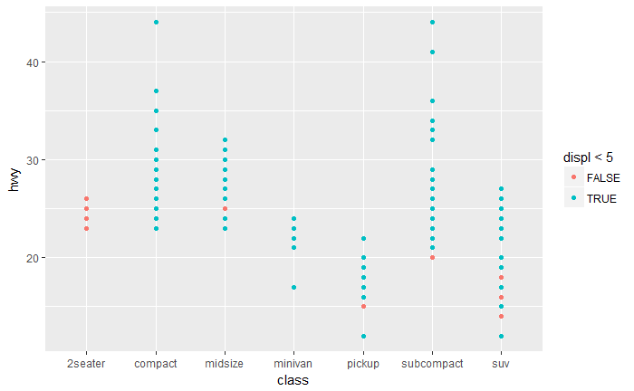

```r
ggplot(data=mpg)+
  geom_point(mapping=aes(x = class, y = hwy,colour = displ < 5))
```

### Exercise 3.5.1

##### 3.

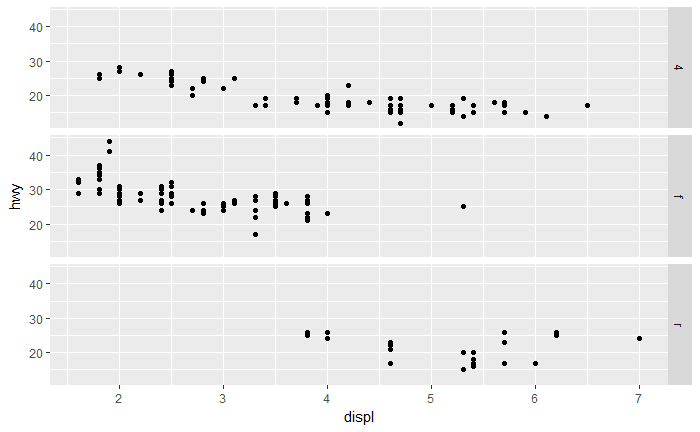

```r
ggplot(data = mpg) +
  geom_point(mapping = aes(x = displ, y = hwy)) +
  facet_grid(drv ~ .)
```

##### facetted by type of drive in rows

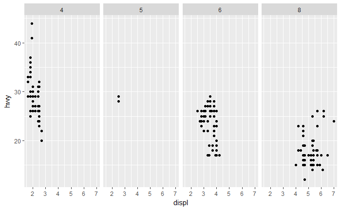

```r
ggplot(data = mpg) +
  geom_point(mapping = aes(x = displ, y = hwy)) +
  facet_grid(. ~ cyl)
```

##### Facetted by number of cylinders in columns

##### 4.

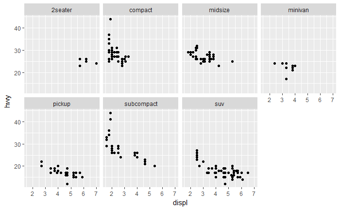

```r
ggplot(data = mpg) +
  geom_point(mapping = aes(x = displ, y = hwy)) +
  facet_wrap(~ class, nrow = 2)
```

##### Advantages to using faceting instead of the colour aesthetic - cleaner, better interpretable visual representation of data; many colors may make graphs to cluttered. Disadvantages - does not give you the best relative representation (between the facets). For larger datasets with many facet elements, break them down into separate graphs may produce many graphs that do not fit on the same page and become deifficult to interpret.

##### 5. nrow specifies number of rows the graphic will be presented in; ncol number of columns the graphic will be presented in.

##### Other options that control the layout of the individual panels: dir - Direction: either “h” for horizontal, the default, or “v”, for vertical; scales - vary the scales of each panel

##### facet_grid() does not have nrow and ncol argument because it’s a matrix of two variables that are specified by user, hence it will be auto-generated.

```r
?facet_wrap
```

### Exercise 3.6.1

##### 1.To draw a line chart use geom_smooth(); a boxplot - geom_boxplot(); a histogram - geom_histogram(); an area chart - geom_area

##### 2. The code will output a two layer graph: data points - dots for hwy vs displacement; data points will differ in color by drv. overlayed on top will be a set of line graphs of displ vs. hwy by drv type; all lines will not have shaded confidence interval

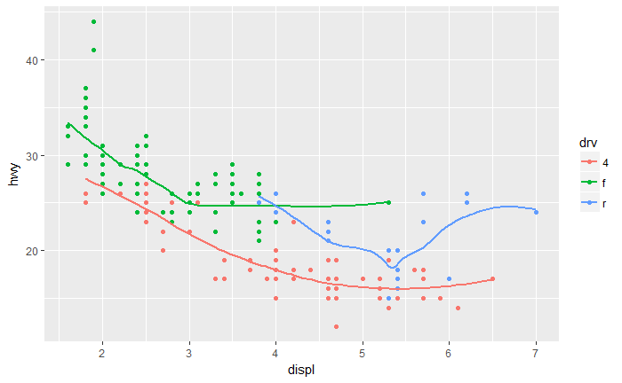

```r
ggplot(data = mpg, mapping = aes(x = displ, y = hwy, color = drv)) +
  geom_point() +
  geom_smooth(se = FALSE)
```

##### 3.

###### show.legend = FALSE hides the legend. it was removed prior to give more space to show graphs

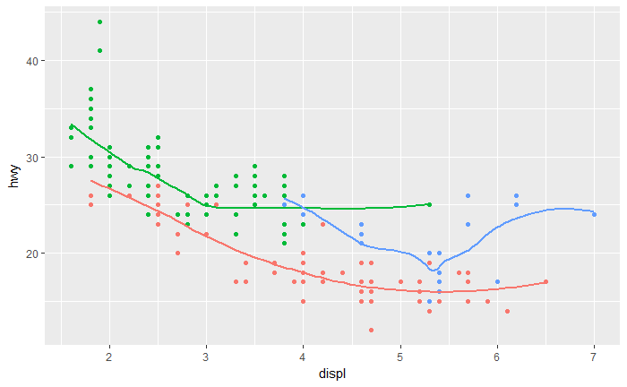

```r
ggplot(data = mpg, mapping = aes(x = displ, y = hwy, color = drv)) +
  geom_point(show.legend = FALSE) +
  geom_smooth(se = FALSE, show.legend = FALSE)
```

##### 4. se argument shows the confidence interval, default at 95%; can be controlled via level argument

##### 5.Graphs will look the same since they have exaclty the same arguments. First chunk of code outlines arguments for geom_point and geom_smooth under ggplot(). The second chunk of code outlines the same exact arguments in each geom separately

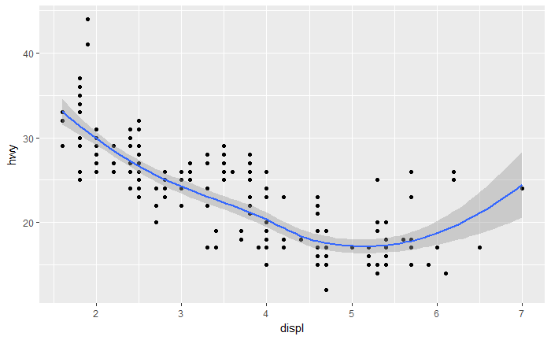

```r
ggplot(data = mpg, mapping = aes(x = displ, y = hwy)) +
  geom_point() +
  geom_smooth()
```

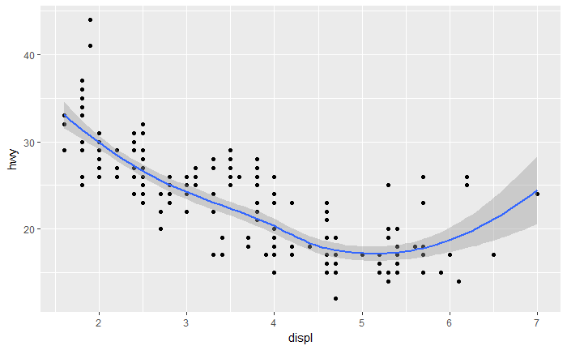

```r
ggplot() +
  geom_point(data = mpg, mapping = aes(x = displ, y = hwy)) +
  geom_smooth(data = mpg, mapping = aes(x = displ, y = hwy))
```

### Exercise 3.7.1

##### 2. geom_col() - heights of the bars represent values in the data; geom_bar() - makes the height of the bar proportional to the number of cases in each group

### Additional Questions:

##### What works? sentance long summarized insights

##### What doesn’t work? donut charts are difficult to grasp and interpret. grapho of where data scientists are involved in the cycle has too many panels that are hard to grasp in totality

##### What would you have done differently? would have used stacked bar to potray data scientists backgrounds instead of differently sized bubbles.

### Exercise 3.6.1 #6

##### Graph 1

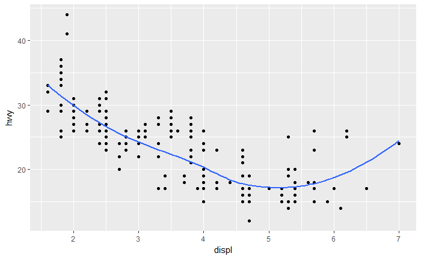

```r
ggplot(data = mpg, mapping = aes(x = displ, y = hwy)) +
  geom_point() +
  geom_smooth(se = FALSE)
```

##### Graph 2

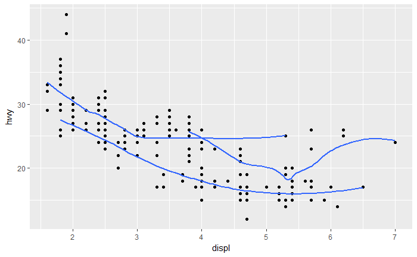

```r
ggplot(data = mpg, mapping = aes(x = displ, y = hwy, line=drv)) +
  geom_point() +
  geom_smooth(se = FALSE)
```

##### Graph 3

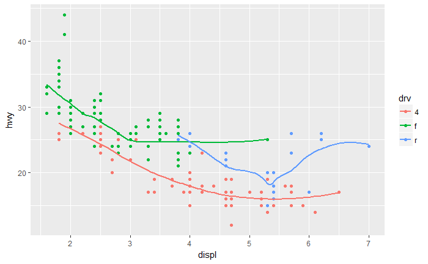

```r
ggplot(data = mpg, mapping = aes(x = displ, y = hwy, color=drv)) +
  geom_point() +
  geom_smooth(se = FALSE)
```

##### Graph 4

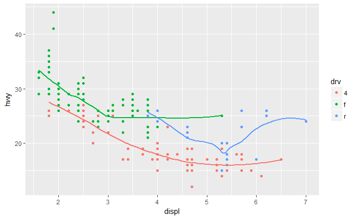

```r
ggplot(data = mpg, mapping = aes(x = displ, y = hwy, color=drv)) +
  geom_point() +
  geom_smooth(se = FALSE, show.legend= FALSE)
```

##### Graph 5

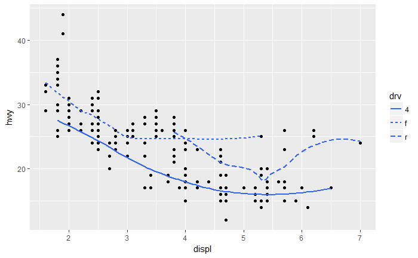

```r
ggplot(data = mpg, mapping = aes(x = displ, y = hwy, linetype=drv)) +
  geom_point() +
  geom_smooth(se = FALSE)
```

##### Graph 6

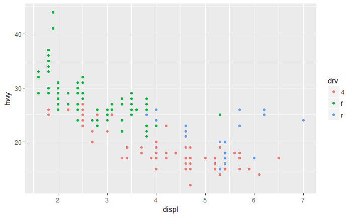

```r
ggplot(data = mpg, mapping = aes(x = displ, y = hwy, color=drv)) +
  geom_point()
```

### End of Homework 2